# Assessing feature importance for sgRNA using supervised machine learning

Alec Thomsen, Emil Carlstedt

2025-05-29

## Introduction

The discovery of CRISPR-Cas9 has led to innumerable possibilities in the field of biotechnology. One of them involves the use of single-guide RNA engineered to target specific genes of interest in order to do knock-out experiments. Understanding how to design these sgRNAs is crucial to the experiments success, therefore guide lines have been developed. Although the guidelines differ for different species they have been shown to be effective.(Schindele *et al.* 2020) Our interest is to find out just which of the features are most important for the efficiency of the sgRNA. To tackle this issue we will employ a tactic involving supervised machine learning. This will help us assess what features of a sgRNA are most important for its effectiveness.

## Theory

The sgRNA dataset we chose to use was of the GeCKO v2 sgRNA library, and it was designed to give high-throughput genome wide knockout screening Therefore when using this data we assume that these sgRNA’s reliably bind to their respective target binding site, and bind with high accuracy.

## Implementation

### Data Collection

For this project, we decided to use four large datasets to determine the efficiency of the sgRNAs. First, we needed the sgRNA file with the library count and dropout count, which is used to calculate the LFC. Since our plan was to later use the LFC as a major guideline in model prediction, this dataset is the core of the model.

Next, we integrated a translation file that converted the sgRNA IDs from the sgRNA file into their respective 20bp-long sequences, since this sequence will be the model input from which the LFC is predicted.

Furthermore, we wanted to add another parameter to our model: the number of the exon to which a sgRNA was bound. The reasoning was that the later the exon it binds to, the more likely it is to result in an unsuccessful knockout. We hoped to find a correlation there. To do this, we used our translated sgRNA file along with a Human Annotation Reference Genome file, which provided exon numbers, exon start and end positions, and the entire human sequence. Using this information, a sequence alignment was performed to trace each sgRNA to its exact exon. Below is pseudocode explaining this exon extraction procedure:

```
LOAD libraries and files.
JOIN sgRNA_file with Gene annotation file ON matched genes. (Pick one random splicing variant)
EXTRACT last 12 bp's of each sgRNA

For each sgRNA:

GET gene region intervall
EXTRACT sequence of that region (From correct chromosome)
ALIGN sgRNA seq with sequence
MATCH alignment position to find exon number
STORE exon number In new row
```

Lastly, we took three control samples from another study that performed RNA-seq of the entire transcriptome of a cell in normal conditions for all genes, averaged their expression, and matched it to the corresponding gene. The final table that was used for data preprocessing looks as follows:

```r
head(dbGetQuery(mydb, "SELECT * FROM raw_data LIMIT 4"))
```

```
##                  sgrna  Gene GeCKO library_count Dropout_count     LFC
## 1 TGACAACACTTACTACAAAG  TPX2              362.21             0 -8.5047
## 2 ACCCAACAATACCACCGACC  EIF6              361.31             0 -8.5011
## 3 CAGGCTCCTCGTCCATCCAC RPS4X              347.79             0 -8.4462
## 4 CACGCCACTGCACTCCAGCC  OSTC              329.77             0 -8.3697
##   control_var adj_var  score      p.low  p.high p.twosided       FDR
## 1       65598   17164 3.9570 3.7946e-05 0.99996 7.5892e-05 0.0043684
## 2       65272   17094 3.9557 3.8156e-05 0.99996 7.6311e-05 0.0043904
## 3       60480   16060 3.9356 4.1498e-05 0.99996 8.2996e-05 0.0047042
## 4       54375   14720 3.9076 4.6605e-05 0.99995 9.3210e-05 0.0051477
##   high_in_Dropout sgrna_last12 matched_exons  avg_ctrl index
## 1               0   TACTACAAAG             5  7335.667     1
## 2               0   ACCACCGACC             5  1971.000     2
## 3               0   GTCCATCCAC             5 23655.667     3
## 4               0   CACTCCAGCC          <NA>  1781.333     4
```

### Pre-Processing

The features of interest; nucleotide position, gc content, exon position, and RNA sequencing expression were extracted from the database. NA values were omitted and RNA-seq expression was log2 transformed for easier interpretation. Only the sgRNA with RNA-seq expression above 1 were kept as they interpreted as actively transcribed genes. An initial look at the distribution of the features was done using a box plot (See *Figure 1*). This identified a skewed distribution of the data, especially in the feature exon position.

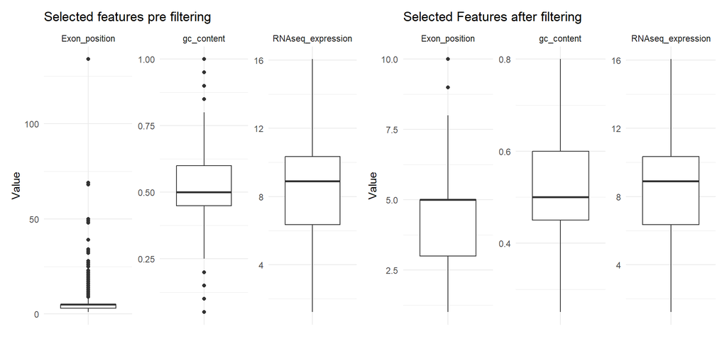

Figure 1. Boxplots displaying the distribution of selected features (exon_position, gc_content, and RNAseq_expression). The plot to the left displays the data pre filtering and the one on the right after filtering. Looking specifically on the boxplot for exon_position we can see that there are a outliers that skews the data, this is adress by the removal of the outliers.

We then filtered the data, only keeping those with a negative LFC. We then used the absolute value of the LFC as our dependent variable for the model.  
The data was split into training and test sets using a 80/20 split. Using the hyper parameters seen in *Table 1*, the model underwent a 5-fold cross-validation, for 1000 rounds with early stopping after 10, in order to find the best boosting round.

Table 1. Model Parameters

| Parameter | Value |
| --- | --- |
| eta | 0.1 |
| max_depth | 4 |
| gamma | 1 |
| objective | reg:squarederror |
| eval_metric | rmse |

This resulted in a optimal boosting round of 115 which was implemented when training the model on the training data.  
After the training SHAP values were calculated as seen in *Figure 2*. Here we can see that highly expressed genes are positively related to a large LFC value, these genes could possible be viewed as “householding” genes and have a vital part in the cell. Nucleotide position has unclear results for example position 20 where all nucleotides have a negative impact on the model which goes against previous studies saying that the later positions are more important.

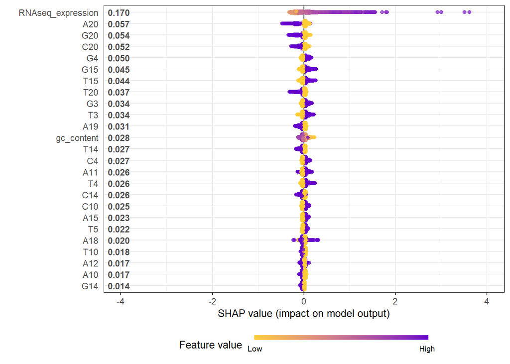

Figure 2. SHAP values for the final model. RNA-seq expression can be seen as the highest contributing feature to the models prediction. Higher RNA expression leads to higher LFC.

After training the model was used to predict the LFC on the testing data that was withheld from training. The RMSE and MAE were not that large but the R2 was very low, meaning the model can make semi accurate predictions but is unable to explain the variance in the data.(See *Table 2*).

Table 2. Evaluation Metrics for Final Model.

| model_rmse | model_mae | model_r2 |
| --- | --- | --- |
| 1.123658 | 0.7823011 | 0.1005288 |

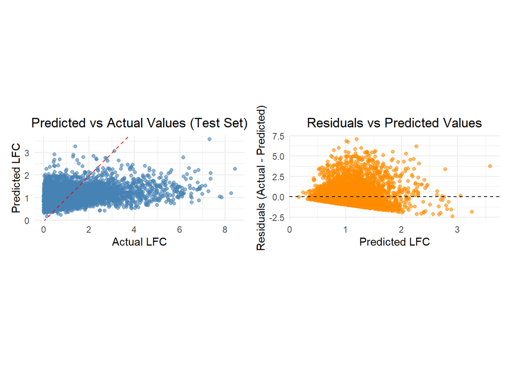

Figure 3 (left) displaying a pattern that the model can only predict values between 0.5 and 1.5 regardless of the actual value. Figure 4 (right) Displaying a fanning pattern, suggesting heteroscedascity.

## Evaluation

Our model is unable to find a pattern in the data we trained it on and therefore the SHAP values are not trustworthy. No conclusions towards our original goal can be drawn based on our results.  
This is most likely to the lack of larger scores in the data as seen in distribution of LFC(See Figure 1A in appendix).  
Testing different models and different targets could also be an option for further testing if more time was available. Using LFC as a target might not have been the best choice as we would only get on successful knock outs that targeted a vital gene. We tried to work around this by filtering out LFCs that were not of interest but this also means that we loose a lot of data. Using transcriptomic data for creating a classification on successful knock outs would result in minimum loss of data as even non vital genes would be included. Of course there are other difficulties with that approach. Would you use a binary approach saying that if its below a baseline with a certain amount its regarded a knock out or do you create different levels of success based on how much the transcription is reduced. And how do you decide on these limits? A lot of questions arise once you start digging into this subject and if time allows we would like to explore them all.

Furthermore we did an ANOVA test that looked like this:

```r
# Does Exon_position explain absLFC?
anova(lm(absLFC ~ Exon_position, data = model_data))

Response: absLFC
                 Df Sum Sq Mean Sq F value Pr(>F)
Exon_position     1      1  1.1346  0.8162 0.3663
Residuals     31634  43977  1.3902



# Does gc_content explain absLFC?
anova(lm(absLFC ~ gc_content, data = model_data))
Analysis of Variance Table

Response: absLFC
              Df Sum Sq Mean Sq F value    Pr(>F)
gc_content     1    113 112.897  81.416 < 2.2e-16 ***
Residuals  31634  43866   1.387
---
Signif. codes:  0 ‘***’ 0.001 ‘**’ 0.01 ‘*’ 0.05 ‘.’ 0.1 ‘ ’ 1
```

Here, GC content yields a highly significant p‐value (p < 2.2e-16), but note that it explains only a very small fraction of the total variance (around 0.26%). In conclusion although the relationship is statistically significant, the effect size is practically negligible.

## Appendix

Figure 1A

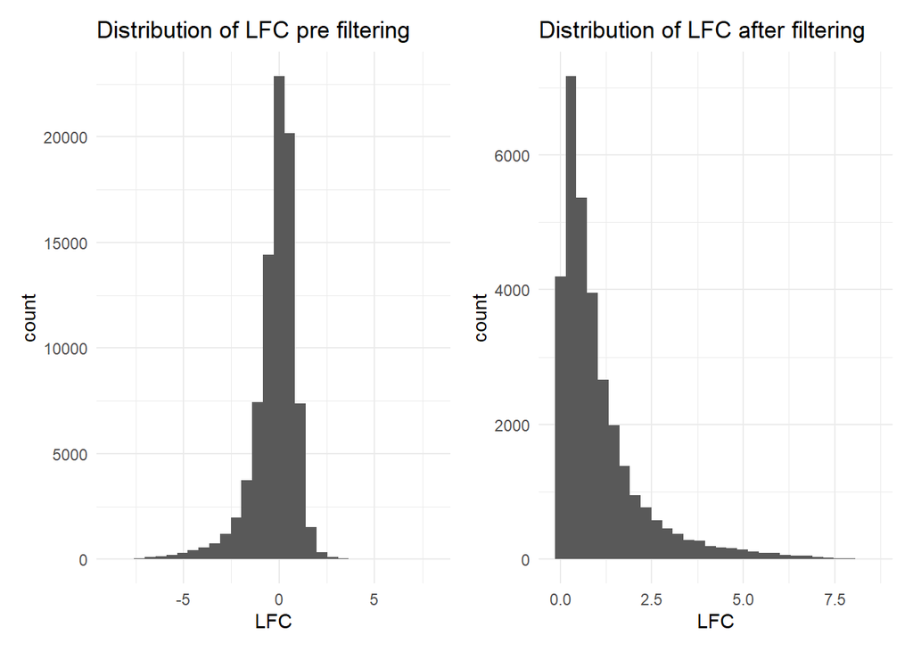

## References

Schindele, P., Wolter, F., and Puchta, H. (2020) ‘CRISPR guide RNA design guidelines for efficient genome editing’, in *Methods in Molecular Biology*, Humana, New York, NY, 331–342, available: https://doi.org/10.1007/978-1-0716-0712-1_19.